# HW05 Part 2: Data Visualization

#### plot 7

Using same data in plot 4 & 5 to make a boxplot

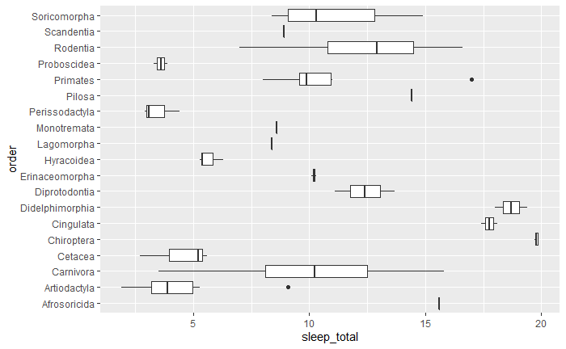

```r
ggplot(data = msleep) +
  geom_boxplot(mapping = aes(x = order, y = sleep_total)) +
  coord_flip()
```

This data is more scattered and difficult to read with the large number of orders. There is less of a pattern to distinguish, than that of plot 4 & 5.

#### Plot 8

Using “msleep” data to make a boxplot with points

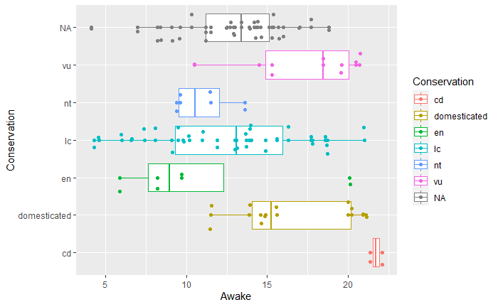

```r
ggplot(data = msleep, mapping = aes(x = conservation, y = awake, color = conservation)) +
  geom_boxplot() +
  geom_point() +
  geom_jitter() +
  coord_flip() +
  labs(x = 'Conservation', y = 'Awake') +
  scale_color_discrete('Conservation')
```

```r
NA
```

#### plot 9

Make a scatterplot of awake variables against body weight.

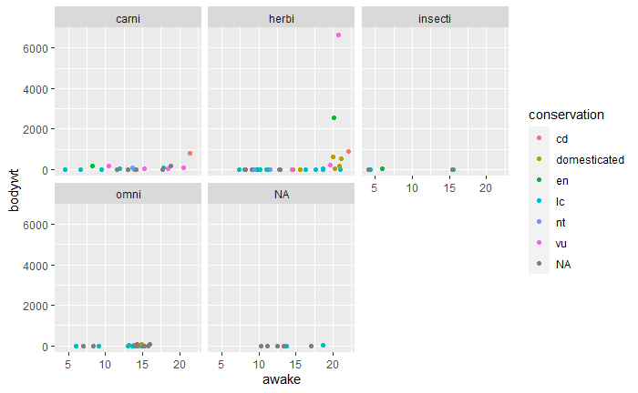

```r
ggplot(data = msleep) +
  geom_point(mapping = aes(x = awake, y = bodywt, color = conservation)) +
  facet_wrap(~ vore, nrow = 2)
```

The values for bodywt make it difficult to see data below 2000. Herbivores are the only ones with a body weight above 2000 and are awake over 20 hours.

#### Plot 10

Make a scatterplot with awake variables against brain weight.

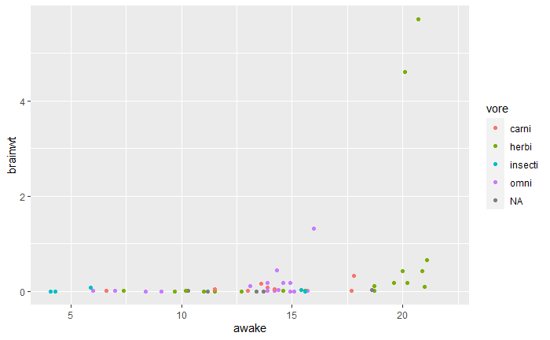

```r
ggplot(data = msleep) +
  geom_point(mapping = aes(x = awake, y = brainwt, color = vore))
```